# Active Learning for Image Classification

# Classifying wood knots

This is a followup to our earlier blog post “[Featurizing images: the shallow end of deep learning](http://blog.revolutionanalytics.com/2017/09/wood-knots.html#more)”. That article contains the code for generating the features for the training and test datasets, which were saved to a csv file. Here we begin by loading that file.

```r
### Libraries ###
library(dplyr)
library(tidyr)
library(ggplot2)

library(pROC)

### Meta-hyperparameters ###
set.seed(3)  ###

L1_PENALTY <- 1e-2
L2_PENALTY <- 1e-2

INITIAL_EXAMPLES_PER_CLASS <- 6  # cases from the labelled dataset used to train the initial model

ADDITIONAL_CASES_TO_LABEL <- 12  # cases to label per iteration

NUM_ITERATIONS <- 15 # 10

MONTE_CARLO_SAMPLES <- 100

# This order determines the order of factor levels
KNOT_CLASSES <- setNames(nm=c("sound_knot", "dry_knot", "encased_knot"))

LABELLED_FEATURIZED_DATA <- "data_old/labelled_knots_featurized_resnet18.Rds"
UNLABELLED_FEATURIZED_DATA <- "data_old/unlabelled_knots_featurized_large_resnet18.Rds"

unlabelled_knot_data_df <- readRDS(UNLABELLED_FEATURIZED_DATA)
labelled_knot_data_df <- readRDS(LABELLED_FEATURIZED_DATA)

PSEUDOLABELS_FILE <- "data_old/unlabelled_knot_info_area_small.csv" # "unlabelled_knot_info.csv" # We'll pretend these come from our labellers

inputs <- grep("^Feature", names(labelled_knot_data_df), value=TRUE)
outcome <- "knot_class"
FORM <- formula(paste(outcome, paste(inputs, collapse="+"), sep="~"))
```

### Split labelled data into training and test sets

```r
class_samples <- lapply(KNOT_CLASSES, function(kc) sample(which(labelled_knot_data_df$knot_class == kc), INITIAL_EXAMPLES_PER_CLASS))

in_training_set <- (1:nrow(labelled_knot_data_df) %in% unlist(class_samples))

initial_training_set <- labelled_knot_data_df[in_training_set,]
TEST_SET <- labelled_knot_data_df[!in_training_set,]

table(initial_training_set$knot_class)
```

```
##
##   sound_knot     dry_knot encased_knot
##            6            6            6
```

```r
table(TEST_SET$knot_class)
```

```
##
##   sound_knot     dry_knot encased_knot
##          173           63           23
```

```r
table(TEST_SET$knot_class)/nrow(TEST_SET)
```

```
##
##   sound_knot     dry_knot encased_knot
##   0.66795367   0.24324324   0.08880309
```

## Initial model for knot classes

First we build a model on the available training data, and test on the test data. This model will focus on classifying a knot image into three categories: “sound_knot”, “dry_knot”, and “encased_knot”. In the blog post there was also a category for “decayed_knot”, but we will consider decay a separate attribute, and not use it in this model. We will use only a small number of the available labelled cases for training, and the rest for testing. This makes a larger test set and a smaller training set than in the blog post.

### Fit model to initial training set

```r
source("woodknots_active_learning_lib.R")

pseudolabel_function <- get_pseudolabelling_function(PSEUDOLABELS_FILE, KNOT_CLASSES)

initial_model_results <- fit_and_evaluate_model(initial_training_set)

select_cases <- function(model, available_cases, N=ADDITIONAL_CASES_TO_LABEL){
  predictions_df <- rxPredict(model, available_cases, extraVarsToWrite=c("path"))
  names(predictions_df) <- c("path", "pred_class", "sound_knot", "dry_knot", "encased_knot")

  predictions_df$cluster_id <- available_cases %>%
    dist(method="euclidean") %>%
    hclust(method="ward.D2") %>%
    cutree(k=N)

  selected <- predictions_df %>%
    mutate(entropy=entropy(sound_knot, dry_knot)) %>%
    group_by(cluster_id) %>%
    arrange(-entropy) %>%
    slice(which.max(entropy)) %>%
    as.data.frame

  return(selected)

}

initial_model_results$selected <- select_cases(initial_model_results$model, unlabelled_knot_data_df)
```

```
## Elapsed time: 00:00:00.0847065
```

## Results for initial model

### ROC curves

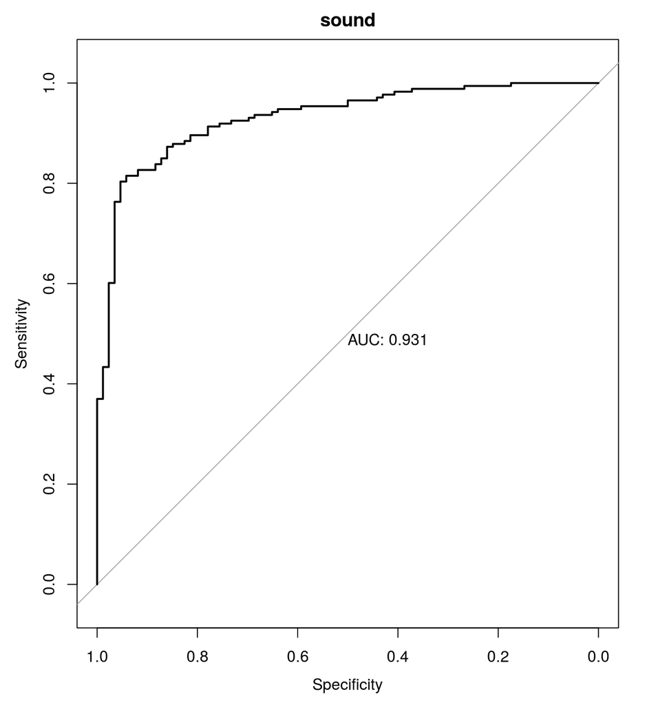

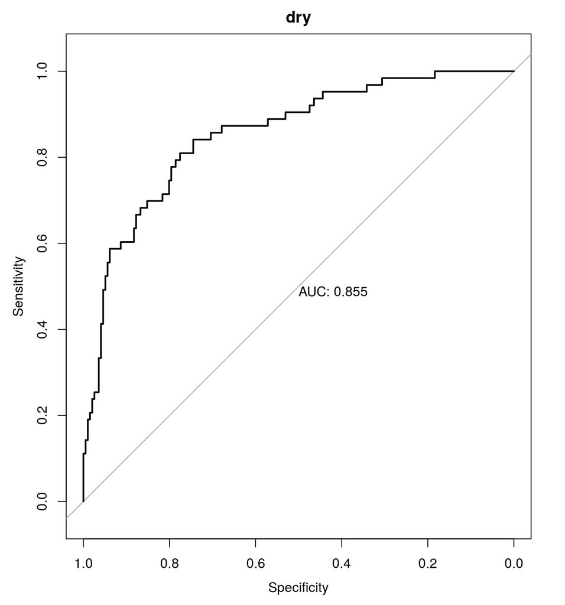

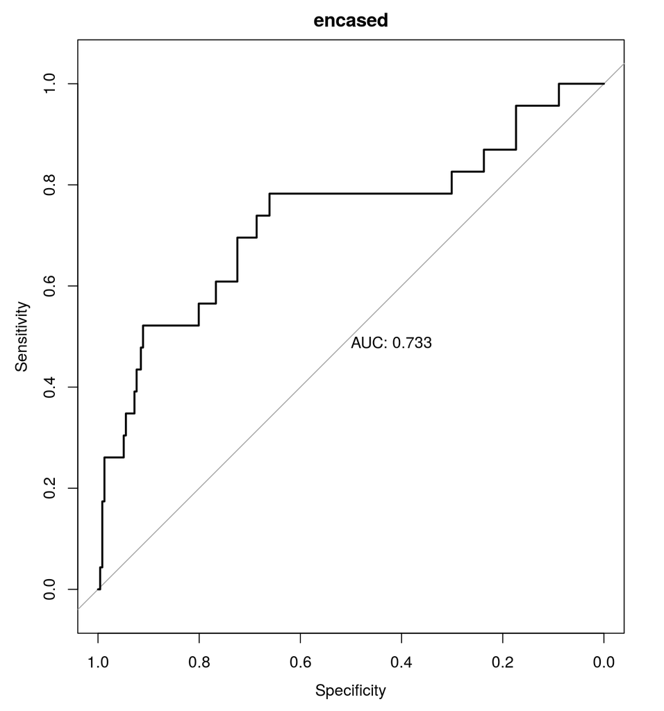

```r
mapply(plot, x=initial_model_results$roc_list, main=names(initial_model_results$roc_list), print.auc=TRUE) %>% invisible
```

#### Confusion matrix

```r
initial_model_results$confusion
```

```
##               pred_class
## knot_class     sound_knot dry_knot encased_knot
##   sound_knot          115       41           17
##   dry_knot              1       52           10
##   encased_knot          2        9           12
```

### Performance summary

```r
initial_model_results$performance
```

```
##    accuracy neg_logloss   auc_sound     auc_dry auc_encased  negentropy
##   0.6911197  -0.2402685   0.9309719   0.8546323   0.7328666  -0.6919870
```

### Histograms of class scores

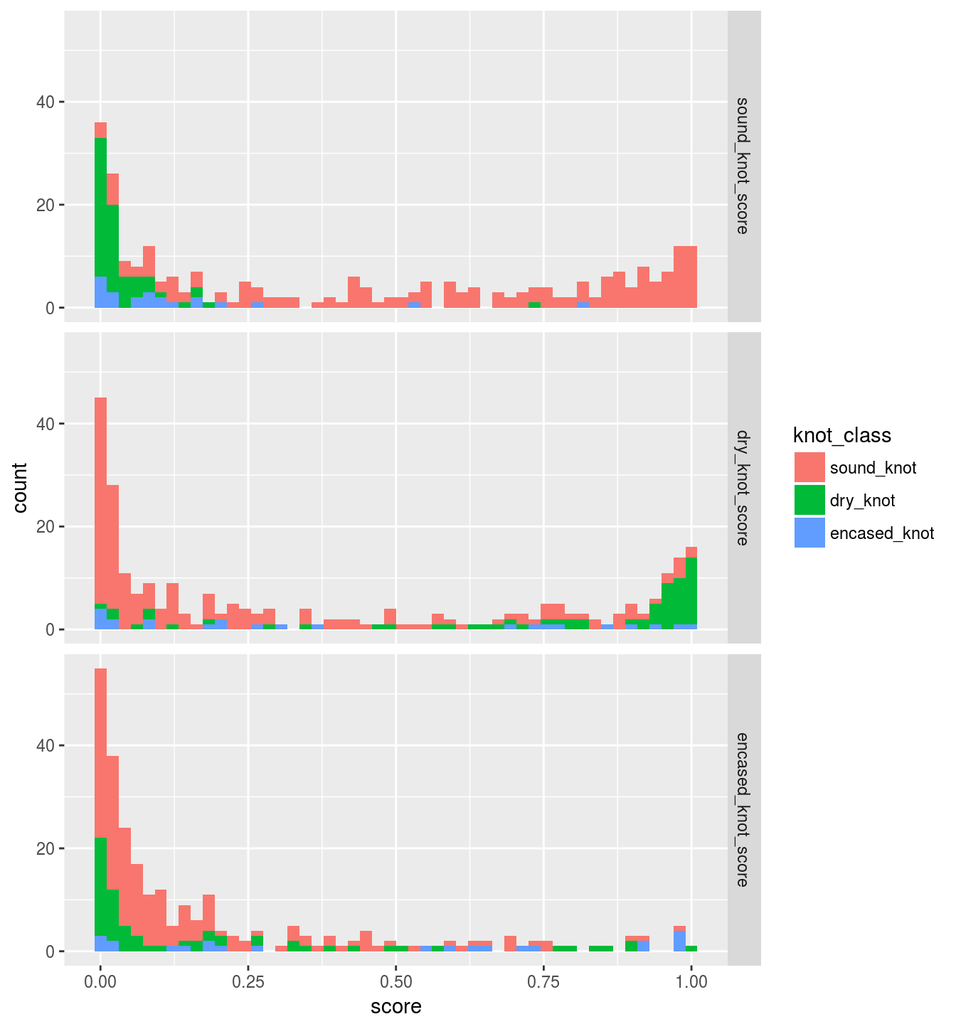

```r
plot_class_histograms(initial_model_results$test_predictions)
```

### Plot of test cases on entropy surface

Here we’ll stick to a 2D representation, where the yellow background indicates regions of lower entropy.

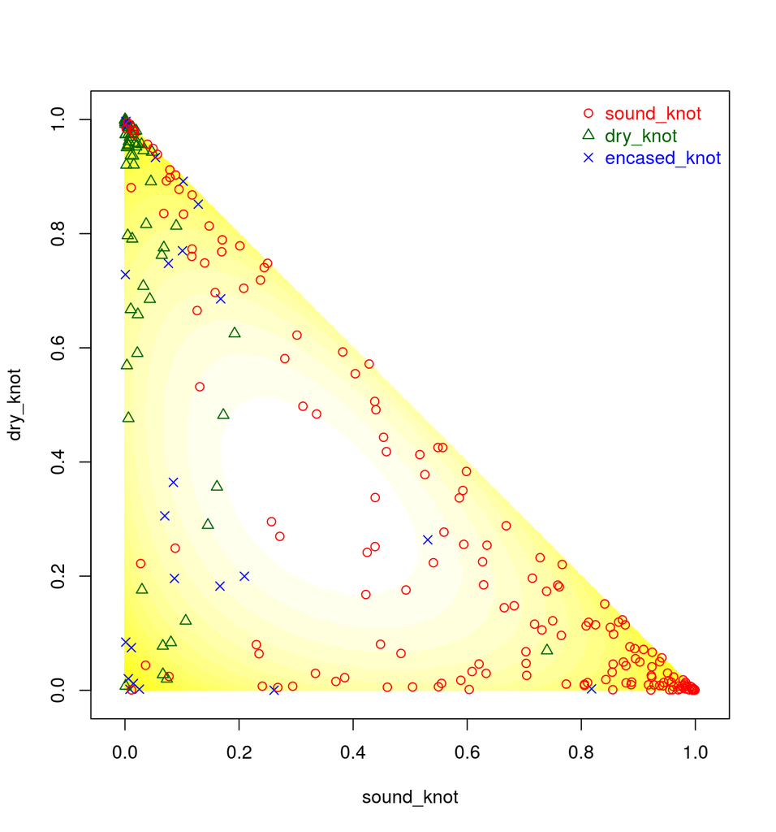

```r
plot_class_separation(initial_model_results$test_predictions)
```

## Iterate modelling, case selection, and (pseudo) labelling

These are the cases selected by the initial model for labelling:

```r
initial_model_results$selected
```

```
##                path   pred_class  sound_knot  dry_knot encased_knot
## 1  st1081_knot0.png     dry_knot 0.120875269 0.4460834   0.43304124
## 2  st1013_knot1.png   sound_knot 0.383779436 0.3796133   0.23660728
## 3  st1782_knot1.png encased_knot 0.006071985 0.4637949   0.53013319
## 4  st1537_knot1.png encased_knot 0.255623758 0.2983799   0.44599631
## 5  st1279_knot1.png     dry_knot 0.290258050 0.4923574   0.21738455
## 6  st1569_knot1.png encased_knot 0.364270538 0.2430272   0.39270243
## 7  st1436_knot2.png     dry_knot 0.265086949 0.5255339   0.20937918
## 8  st1145_knot1.png     dry_knot 0.441458732 0.4875329   0.07100827
## 9  st1535_knot1.png encased_knot 0.135958567 0.3684990   0.49554238
## 10 st1350_knot2.png     dry_knot 0.035429452 0.6553839   0.30918658
## 11 st1166_knot0.png     dry_knot 0.287731797 0.3626657   0.34960252
## 12 st1408_knot1.png encased_knot 0.300205886 0.2409164   0.45887765
##    cluster_id  entropy
## 1           1 1.410857
## 2           2 1.552729
## 3           3 1.044177
## 4           4 1.543190
## 5           5 1.499902
## 6           6 1.556241
## 7           7 1.467855
## 8           8 1.297018
## 9           9 1.424074
## 10         10 1.093837
## 11         11 1.577869
## 12         12 1.531542
```

```r
new_sample <- initial_model_results$selected %>% pseudolabel_function %>% get_new_pseudolabelled_sample

current_training_set <- rbind(initial_training_set, new_sample[names(initial_training_set)])

ALREADY_EVALUATED <- initial_model_results$selected$path

iteration_results <- lapply(1:NUM_ITERATIONS, function(i){
  results <- fit_and_evaluate_model(current_training_set)

  candidate_cases <- unlabelled_knot_data_df[(unlabelled_knot_data_df$path %in% setdiff(unlabelled_knot_data_df$path, ALREADY_EVALUATED)),]
  results$selected <- select_cases(results$model, candidate_cases)

  ALREADY_EVALUATED <<- c(ALREADY_EVALUATED, results$selected$path)
  results$selected_labelled <- results$selected %>% pseudolabel_function
  next_sample <- results$selected %>% pseudolabel_function %>% get_new_pseudolabelled_sample

  current_training_set <<- rbind(current_training_set, next_sample[names(current_training_set)])

  results
})
```

```
## Elapsed time: 00:00:00.0840588
## Elapsed time: 00:00:00.0837482
## Elapsed time: 00:00:00.0765641
## Elapsed time: 00:00:00.0814672
## Elapsed time: 00:00:00.0810723
## Elapsed time: 00:00:00.0826056
## Elapsed time: 00:00:00.0787335
## Elapsed time: 00:00:00.0833641
## Elapsed time: 00:00:00.0774668
## Elapsed time: 00:00:00.0702596
## Elapsed time: 00:00:00.0696507
## Elapsed time: 00:00:00.0813703
## Elapsed time: 00:00:00.0758457
## Elapsed time: 00:00:00.0711722
## Elapsed time: 00:00:00.0774759
```

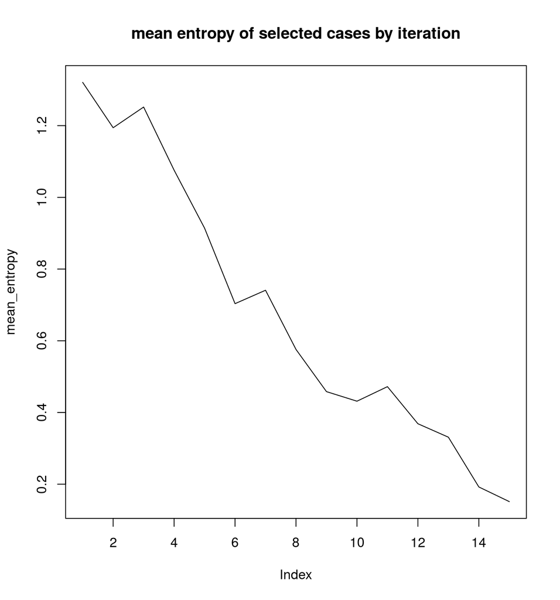

```r
mean_entropy <- sapply(iteration_results, function(ires) mean(ires$selected$entropy))
plot(mean_entropy, type='l', main="mean entropy of selected cases by iteration")
```

These are the cases selected at each iteration, together with the scores produced by the model for that iteration. The `knot_class` column was added by the pseudolabelling function.

```r
lapply(iteration_results, function(ires) ires$selected_labelled)
```

```
## [[1]]
##                path   pred_class sound_knot  dry_knot encased_knot
## 1  st1642_knot1.png     dry_knot 0.03099668 0.5486773 0.4203260839
## 2  st1518_knot2.png     dry_knot 0.11071989 0.5080156 0.3812644780
## 3  st1447_knot3.png encased_knot 0.22456013 0.3576266 0.4178132415
## 4  st1614_knot1.png   sound_knot 0.53804851 0.2642418 0.1977097094
## 5  st1417_knot4.png   sound_knot 0.50446188 0.3577065 0.1378317177
## 6  st1844_knot1.png encased_knot 0.38236335 0.0537101 0.5639265180
## 7  st1405_knot1.png     dry_knot 0.43391439 0.4625725 0.1035130769
## 8  st1312_knot1.png   sound_knot 0.42395377 0.2634231 0.3126230538
## 9  st1082_knot0.png     dry_knot 0.09069306 0.6754227 0.2338842601
## 10 st1412_knot1.png     dry_knot 0.44710442 0.5527936 0.0001021877
## 11 st1430_knot2.png     dry_knot 0.28185195 0.5772408 0.1409072727
## 12 st1337_knot2.png   sound_knot 0.69416887 0.1501439 0.1556873024
##    cluster_id   entropy   knot_class
```

[output cut: 404 more lines]

This shows the change in the metrics, with each row showing an iteration. The ‘negentropy’ metric is the negative entropy across all three class probabilities.

```r
do.call("rbind", lapply(iteration_results, function(ires) ires$performance))
```

```
##        accuracy neg_logloss auc_sound   auc_dry auc_encased negentropy
##  [1,] 0.6679537 -0.18949153 0.8428552 0.8127632   0.7184967 -0.5554615
##  [2,] 0.7876448 -0.14003865 0.9155128 0.8647554   0.7962417 -0.4327121
##  [3,] 0.8146718 -0.13375226 0.9352063 0.8824911   0.8351142 -0.4018812
##  [4,] 0.8223938 -0.12111765 0.9543621 0.9120505   0.8224024 -0.3639284
##  [5,] 0.8455598 -0.09791410 0.9678048 0.9278426   0.8551953 -0.2915946
##  [6,] 0.8648649 -0.08534140 0.9770803 0.9455782   0.8399042 -0.2620245
##  [7,] 0.8764479 -0.08326121 0.9737868 0.9450923   0.8389831 -0.2508613
##  [8,] 0.8725869 -0.07314762 0.9733163 0.9422579   0.8358511 -0.2278352
##  [9,] 0.8610039 -0.06732315 0.9722409 0.9310820   0.8706706 -0.2205886
## [10,] 0.8648649 -0.07118751 0.9730475 0.9320538   0.8857775 -0.2299180
## [11,] 0.8532819 -0.07033566 0.9739884 0.9350502   0.8911201 -0.2131642
## [12,] 0.8648649 -0.05967433 0.9747278 0.9400713   0.8837509 -0.1845936
## [13,] 0.8687259 -0.05872941 0.9735852 0.9310010   0.8898305 -0.1885006
## [14,] 0.8532819 -0.06242963 0.9754671 0.9346048   0.8738025 -0.1893460
## [15,] 0.8648649 -0.05731545 0.9764081 0.9377632   0.8804348 -0.1843171
```

### Visualizing improvement for actively learned model

Here we plot a series of ROC curves showing how performance changes with iterations of active learning.

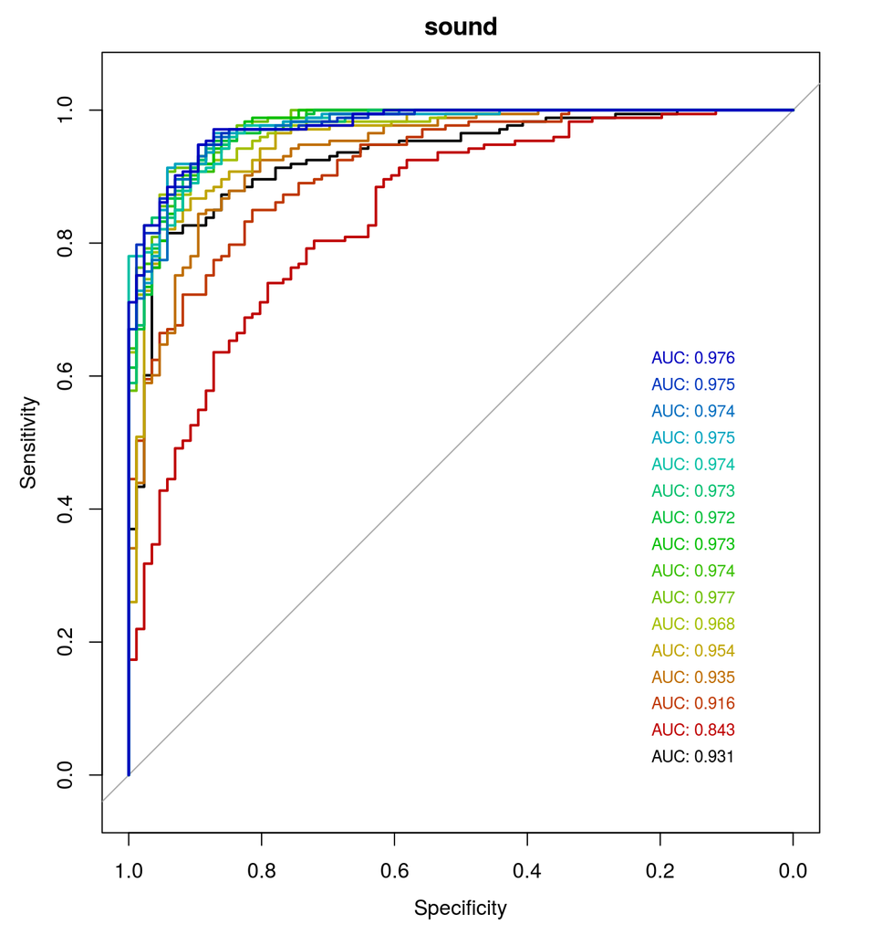

```r
plot_roc_history("sound", initial_model_results, iteration_results)
```

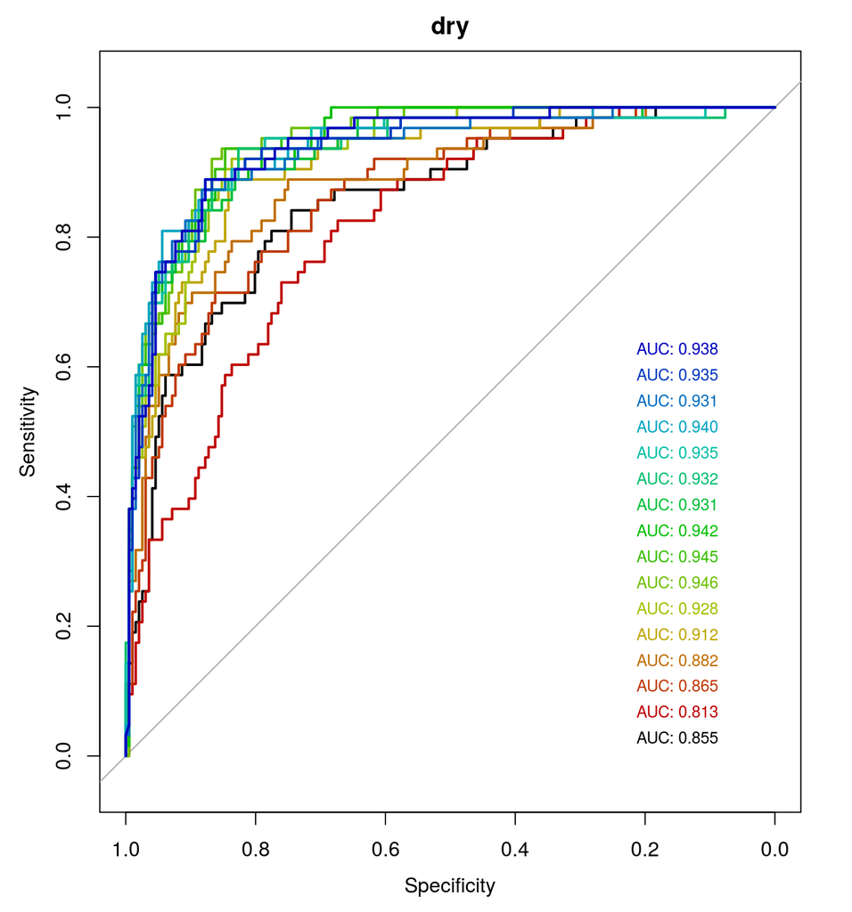

```r
plot_roc_history("dry", initial_model_results, iteration_results)
```

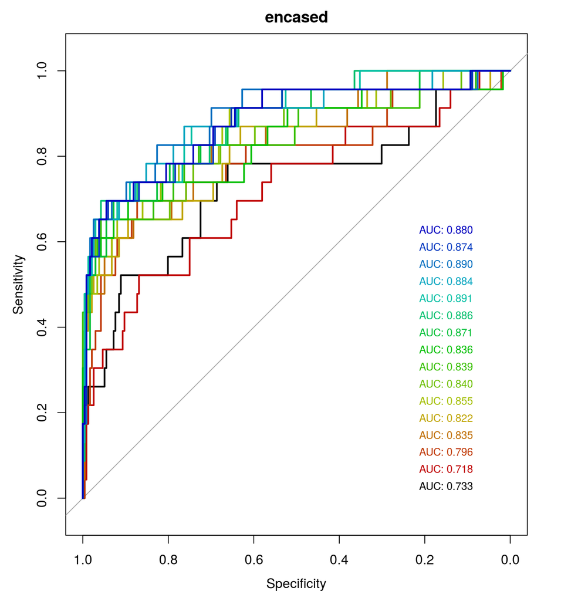

```r
plot_roc_history("encased", initial_model_results, iteration_results)
```

### Final model results

```r
final_model_results <- iteration_results[[NUM_ITERATIONS]]
```

### Confusion Matrix

```r
final_model_results$confusion
```

```
##               pred_class
## knot_class     sound_knot dry_knot encased_knot
##   sound_knot          159       12            2
##   dry_knot              8       51            4
##   encased_knot          1        8           14
```

### Performance summary

Summary of performance using cases selected with active learning:

```r
(selected_sample_results <- final_model_results$performance)
```

```
##    accuracy neg_logloss   auc_sound     auc_dry auc_encased  negentropy
##  0.86486486 -0.05731545  0.97640812  0.93776320  0.88043478 -0.18431706
```

### Histograms of class scores for final model

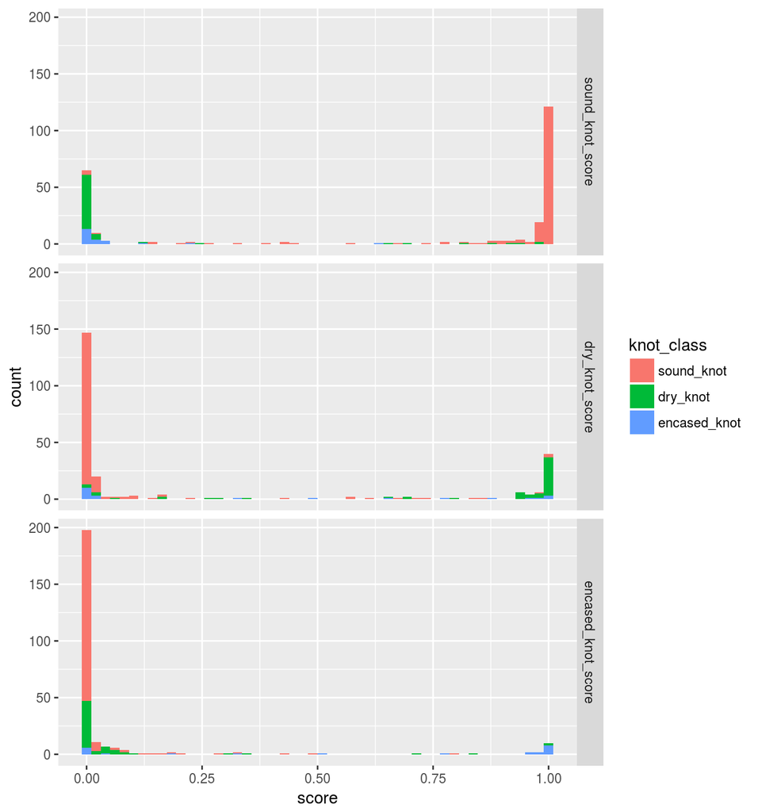

```r
plot_class_histograms(final_model_results$test_predictions)
```

### Entropy surface plot

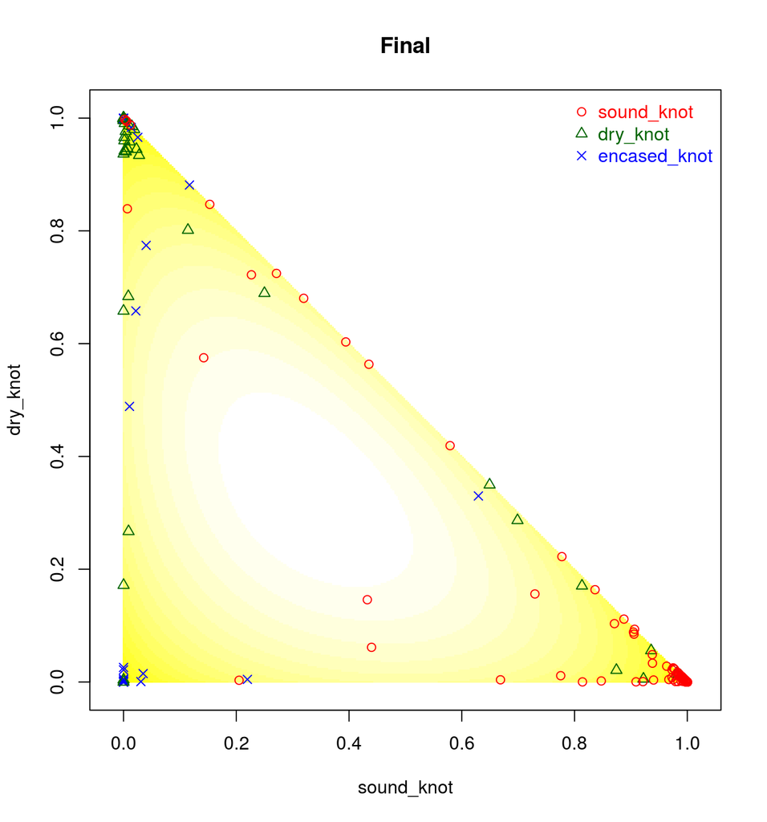

```r
plot_class_separation(final_model_results$test_predictions, main="Final")
```

## Monte Carlo Estimation of P-values

What is the probability that a set of randomly chosen cases would improve the performance of the model as much as the selected cases did? We’ll add the same number of examples to the training set, except that now they will be randomly chosen. We’ll repeat this sampling, training, and evaluation process 100 times, and see how many of those times we beat the performance of the selected cases.

```r
(N <- iteration_results[[NUM_ITERATIONS]]$tss - nrow(initial_training_set))
```

```
## [1] 168
```

```r
available_cases <- pseudolabel_function(unlabelled_knot_data_df)

random_sample_results <- sapply(1:MONTE_CARLO_SAMPLES, function(i){
  new_sample <- available_cases[sample(1:nrow(available_cases), N, replace=FALSE),]

  training_set_new <- rbind(initial_training_set, new_sample[names(initial_training_set)])

  fit_and_evaluate_model(training_set_new)$performance
}) %>% t %>% as.data.frame
```

### P-values

This table shows the fraction of times out of 100 tries that the randomly selected cases equalled or exceeded the performance of the actively learned cases for each metric. These numbers are estimated P-values.

```r
mapply (
  function(metric) sum(random_sample_results[[metric]] >= selected_sample_results[[metric]]),
  colnames(random_sample_results)
) / MONTE_CARLO_SAMPLES
```

```
##    accuracy neg_logloss   auc_sound     auc_dry auc_encased  negentropy
##        0.02        0.02        0.09        0.05        0.46        0.00
```

## Model trained with all available “unlabeled” cases

For comparison, we’ll build a model as though we had gone through and labeled all 373 of the usable new examples.

```r
training_set_full <- rbind(initial_training_set, available_cases[names(initial_training_set)])

full_model_results <- fit_and_evaluate_model(training_set_full)

full_model_results$confusion
```

```
##               pred_class
## knot_class     sound_knot dry_knot encased_knot
##   sound_knot          159       12            2
##   dry_knot              8       45           10
##   encased_knot          0        8           15
```

```r
full_model_results$performance
```

```
##    accuracy neg_logloss   auc_sound     auc_dry auc_encased  negentropy
##  0.84555985 -0.05604914  0.96625891  0.91614027  0.90825350 -0.18887206
```

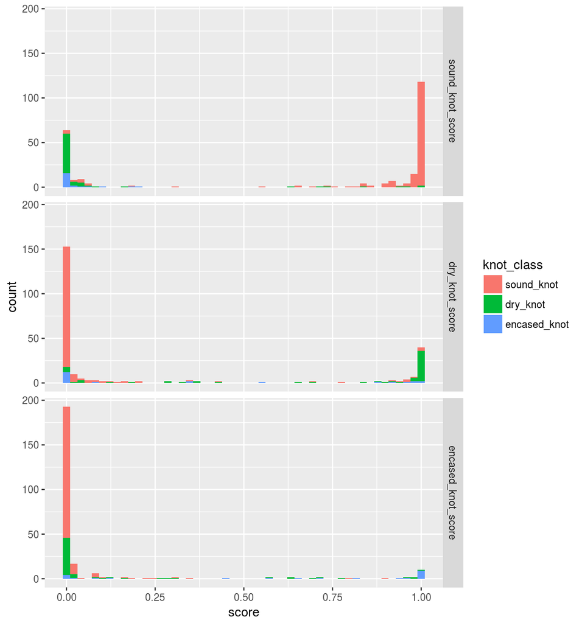

```r
plot_class_histograms(full_model_results$test_predictions)
```

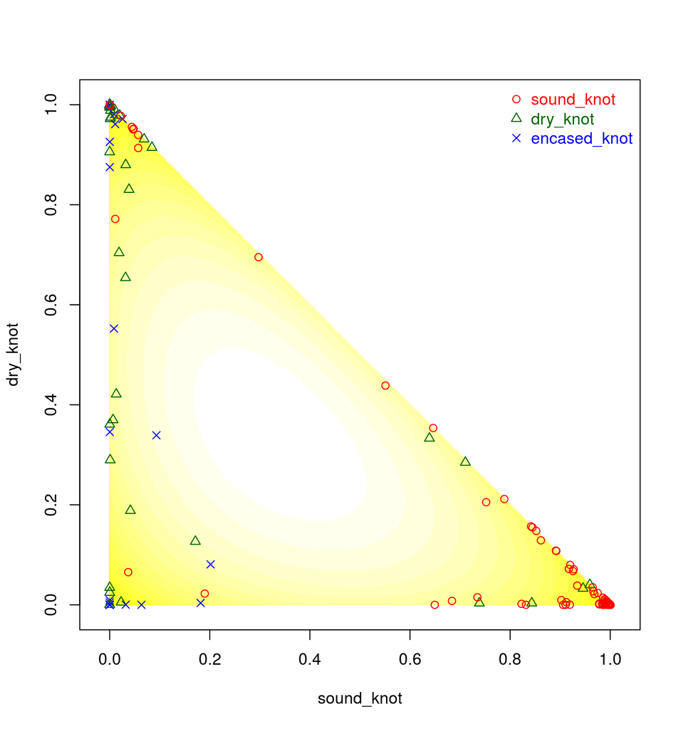

```r
plot_class_separation(full_model_results$test_predictions)
```